# DATA605 Homework11

Henry Otuadinma

08/11/2019

### Using the “cars” dataset in R, build a linear model for stopping distance as a function of speed and replicate the analysis of your textbook chapter 3 (visualization, quality evaluation of the model, and residual analysis.)

```r
data(cars)
cars_df <- cars
```

```r
head(cars_df, 10)
```

```
##    speed dist
## 1      4    2
## 2      4   10
## 3      7    4
## 4      7   22
## 5      8   16
## 6      9   10
## 7     10   18
## 8     10   26
## 9     10   34
## 10    11   17
```

```r
str(cars_df)
```

```
## 'data.frame':    50 obs. of  2 variables:
##  $ speed: num  4 4 7 7 8 9 10 10 10 11 ...
##  $ dist : num  2 10 4 22 16 10 18 26 34 17 ...
```

This data was gotten from measuring the speed and stopping distances of cars in 1920s. It contains only two variables (Speed and Stopping distance) and 50 observations. The numeric Stopping distance is measured in foot (ft)

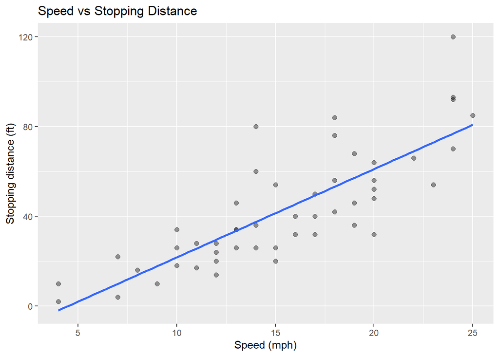

```r
ggplot(cars_df, aes(speed, dist)) +
  geom_point(size = 2, alpha = .4) +
  geom_smooth(method = "lm", se = FALSE, alpha = .2) +
  labs(title = "Speed vs Stopping Distance",
       x = "Speed (mph)",
       y = "Stopping distance (ft)")
```

```r
lm_cars <- lm(speed~dist, data = cars_df)
```

```r
summary(lm_cars)
```

```
##
## Call:
## lm(formula = speed ~ dist, data = cars_df)
##
## Residuals:
##     Min      1Q  Median      3Q     Max
## -7.5293 -2.1550  0.3615  2.4377  6.4179
##
## Coefficients:
##             Estimate Std. Error t value Pr(>|t|)
## (Intercept)  8.28391    0.87438   9.474 1.44e-12 ***
## dist         0.16557    0.01749   9.464 1.49e-12 ***
## ---
## Signif. codes:  0 '***' 0.001 '**' 0.01 '*' 0.05 '.' 0.1 ' ' 1
##
## Residual standard error: 3.156 on 48 degrees of freedom
## Multiple R-squared:  0.6511, Adjusted R-squared:  0.6438
## F-statistic: 89.57 on 1 and 48 DF,  p-value: 1.49e-12
```

#### 3. The model produced a Multiple R-squared of 0.6511, implying that about 65% variation in the stopping distance is accounteed for by the least-squares line.

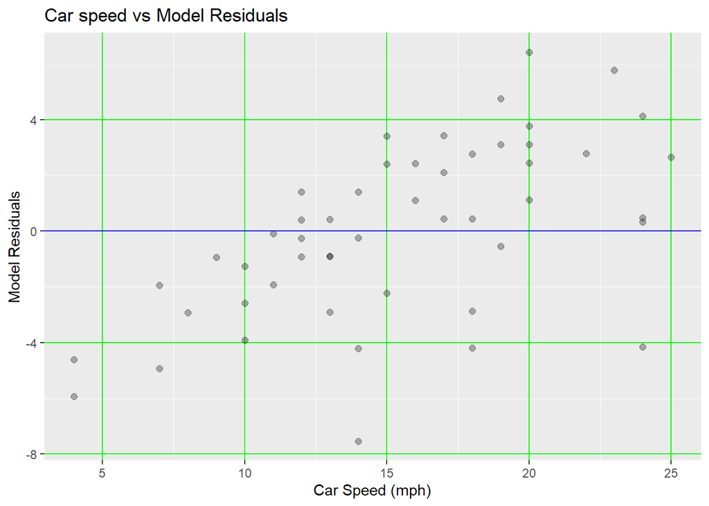

```r
ggplot(data = cars_df, aes(x=speed, y=lm_cars$residuals)) +
  geom_point(size = 2, alpha = .3) +
  geom_abline(intercept = 0, slope = 0, color = "blue") +
  theme(panel.grid.major = element_line(color = "green")) +
  labs(title = "Car speed vs Model Residuals",
       x = "Car Speed (mph)",
       y = "Model Residuals")
```

Using qqnorm to to check if the residuals are nearly normal (exhibit normal distribution).

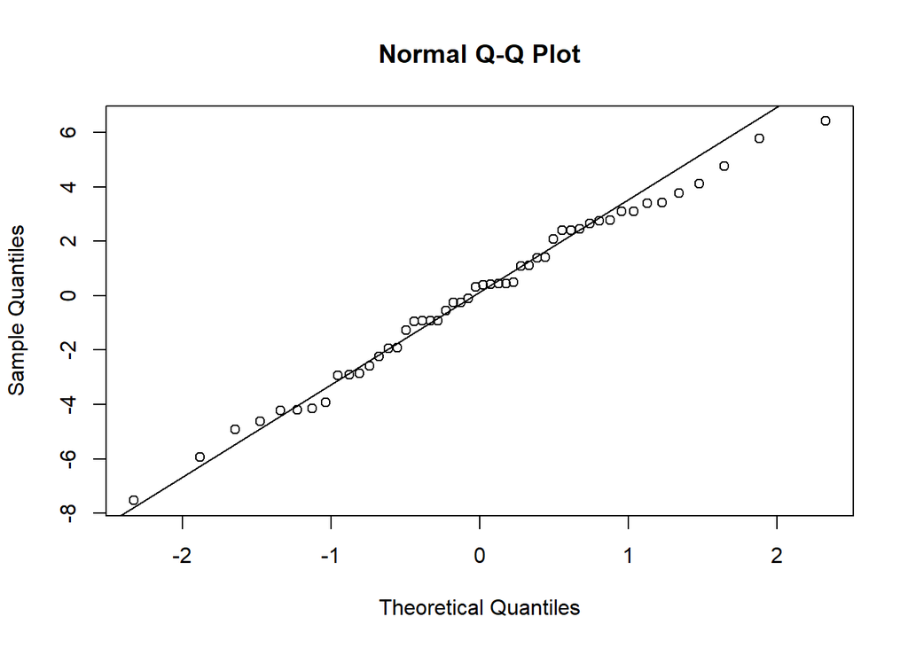

```r
qqnorm(lm_cars$residuals)
qqline(lm_cars$residuals)
```

#### We can observe the residuals have near normal distribution though some tails can be observed.

Reviewing further using a histogram:

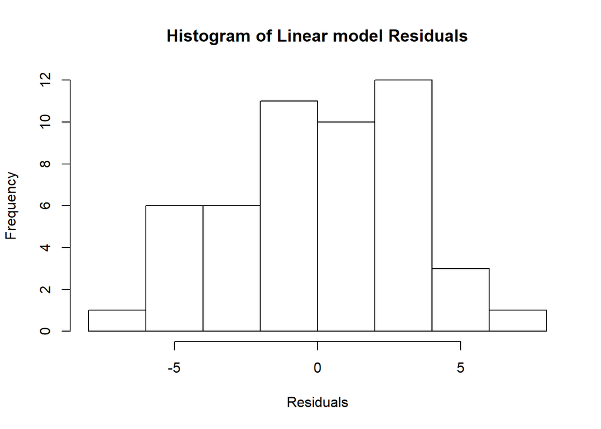

```r
hist(lm_cars$residuals, main="Histogram of Linear model Residuals", xlab="Residuals")
```

There appears to be a modest normal distribution as depicted by the above histogram.

Testing further using inference.

Inference:

#### H0: There is no relationship between speed and stopping distance

#### HA: There is a positive relationship (correlation) between Speed and stopping distance

Rounding up: A look at the model using the summary() function again.

```r
summary(lm_cars)
```

```
##
## Call:
## lm(formula = speed ~ dist, data = cars_df)
##
## Residuals:
##     Min      1Q  Median      3Q     Max
## -7.5293 -2.1550  0.3615  2.4377  6.4179
##
## Coefficients:
##             Estimate Std. Error t value Pr(>|t|)
## (Intercept)  8.28391    0.87438   9.474 1.44e-12 ***
## dist         0.16557    0.01749   9.464 1.49e-12 ***
## ---
## Signif. codes:  0 '***' 0.001 '**' 0.01 '*' 0.05 '.' 0.1 ' ' 1
##
## Residual standard error: 3.156 on 48 degrees of freedom
## Multiple R-squared:  0.6511, Adjusted R-squared:  0.6438
## F-statistic: 89.57 on 1 and 48 DF,  p-value: 1.49e-12
```